# Lista 2

Probabilidade e Estatística – 2020.1

fnaufel

Criado em 07/12/2020 Versão de 22/09/2021

# 1 Distância entre bancos

- Segundo o [Levantamento do Perfil Antropométrico da População Brasileira Usuária do Transporte Aéreo Nacional](https://www2.anac.gov.br/arquivos/pdf/Relatorio_Final_Projeto_Conhecer.pdf), de 2009, a distância glúteo-joelho (ver figura abaixo) do homem brasileiro segue uma distribuição normal com média $\mu = 60{,}7$cm e desvio padrão $\sigma = 3{,}1$cm.

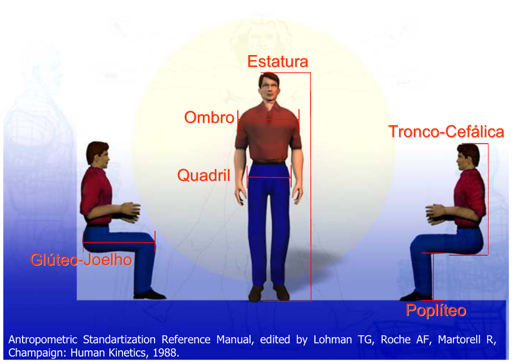

  Em um avião, qual deve ser a distância mínima entre a parte dianteira do encosto de uma poltrona (onde encosta o glúteo) e a parte traseira da poltrona imediatamente à frente (onde encosta o joelho) para que $95\%$ dos homens brasileiros possam caber sentados conforme a figura abaixo?

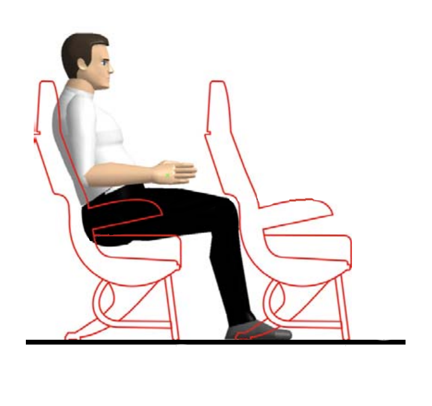

# 2 Caixa de mercado

- Em um caixa de um pequeno mercado, o número de clientes que chegam por minuto é, em média, $4$.
- Vamos representar este número pela variável aleatória $X$, com suporte $\{ 0, 1, 2, 3, \ldots \}$.
- As chegadas dos clientes são independentes umas das outras.
- Se você dividir o tempo em intervalos menores do que um minuto, a média se mantém: $2$ clientes a cada $30$ segundos, $1$ cliente a cada $15$ segundos etc.
- Clientes diferentes não chegam ao caixa no mesmo instante.
- Então, a variável aleatória $X$ segue a distribuição de Poisson, com média $\lambda = 4$.
- Faça uma simulação:
  1. Usando `rpois`, gere uma amostra de $60$ números, correspondendo a $1$ hora de funcionamento do caixa.
  2. Escreva uma função em R para processar esta amostra e retornar um vetor de $60$ elementos: a quantidade de clientes na fila ao final de cada minuto (de $1$ a $60$). Lembre-se de que o caixa processa $4$ clientes por minuto.
  3. Faça um gráfico do número de clientes na fila ao final de cada minuto, ao longo do tempo.
  4. Usando `rpois`, agora gere uma amostra de $60$ números, correspondendo a $1$ hora de funcionamento do caixa, desta vez com uma média de $5$ clientes chegando por minuto.
  5. Use a função que você escreveu para processar esta amostra e retornar um vetor com a quantidade de clientes na fila a cada minuto (de $1$ a $60$), *supondo que o caixa ainda processa só $4$ clientes por minuto*.
  6. Faça um gráfico do número de clientes na fila ao final de cada minuto, ao longo do tempo.

# 3 Pessoas canhotas

- Na população, $12\%$ das pessoas são canhotas.
- Você escolhe $100$ pessoas ao acaso.
- Em relação ao grupo de pessoas escolhidas:
  1. Qual é a média e o desvio padrão da variável aleatória que representa o número de pessoas destras no grupo?
  2. Qual é a probabilidade de nem todas as pessoas do grupo serem canhotas?
  3. Qual é a probabilidade de haver no máximo $75$ pessoas destras no grupo?
  4. Qual é a probabilidade de a maioria das pessoas do grupo serem destras?